# Erik Emilsson’s Portfolio Page

Professional and personal projects.

Author: Erik Emilsson

Date: November 10, 2024

## Introduction

Thank you for visiting my website.

I created it to share with you the results from some of my projects that I’ve had the fortune to be a part of. I hope you find them interesting and that they can be a source of inspiration.

Contact me on LinkedIn

I speak English

Jag pratar svenska

Yo hablo español

From my experience I am convinced that understanding and mastering **data tools** and **cloud services** is the way forward for effective engineering and making accessible technologies for businesses and individuals that can improve *efficiency*, *safety*, and *quality of life*.

## Competency Overview

I have over six year’s experience in **sustainability management consulting** in the product development & purchasing departments of a multi-national manufacturing conglomerate. In parallel, I have **data analytics/science** experience from several EU-funded research projects within electrification and circular economy. From my formal education in B.Sc **chemical engineering** (with engineering physics), and a M.Sc. **applied physics** I have a solid understanding of **applied mathematical modelling** and **statistics**.

I’m a certified [**Power BI data analyst**](https://learn.microsoft.com/api/credentials/share/en-us/ErikEmilsson-8069/5E435A2FA1F8B691?sharingId=BB4E4B973D67B45F) associate and I’m also certified in [**Azure cloud**](https://learn.microsoft.com/api/credentials/share/en-us/ErikEmilsson-8069/B0D068A103061930?sharingId=BB4E4B973D67B45F) and [**Azure AI**](https://learn.microsoft.com/api/credentials/share/en-us/ErikEmilsson-8069/6F71EC0D6B0C4683?sharingId=BB4E4B973D67B45F) fundamentals. I’m also well underway to become certified in end-to-end enterprise analytics as a **Fabric Analytics Engineer** associate.

*“Innovation distinguishes between a leader and a follower.”* - Steve Jobs

Some of my favourite technologies and programming languages that I have used in my professional projects are:

- Microsoft **Power BI** with **DAX** for enterprise dashboards.
- Microsoft **Excel** with **Power Query** for calculations and ETL.
- **Python** for solving discrete optimization problems, ETL, and dynamic visuals.
- **VS Code** as my main code editor.
- Microsoft **Sharepoint** and **Teams** for collaboration.
- **draw.io** for data- and entity-modelling.

I also have experience with the following from courses and personal projects:

- **T-SQL** in Microsoft **SQL Server** and **Azure SQL Services** for learning about data warehouseing and enterprise analytics.
- **PostgreSQL** for learning SQL for local data warehousing.
- Data Warehousing with **Standard SQL** in **GCP’s BiqQuery**
- **Sqlite** for learning SQL for Data Science
- **R**-language data cleaning, transformations, and visualizations.
- **Tableau** for creating visuals in dashboards.
- **PySpark** for learning real-time enterprise analytics.

## Professional Projects

*Under construction.*

#### ELiMINATE

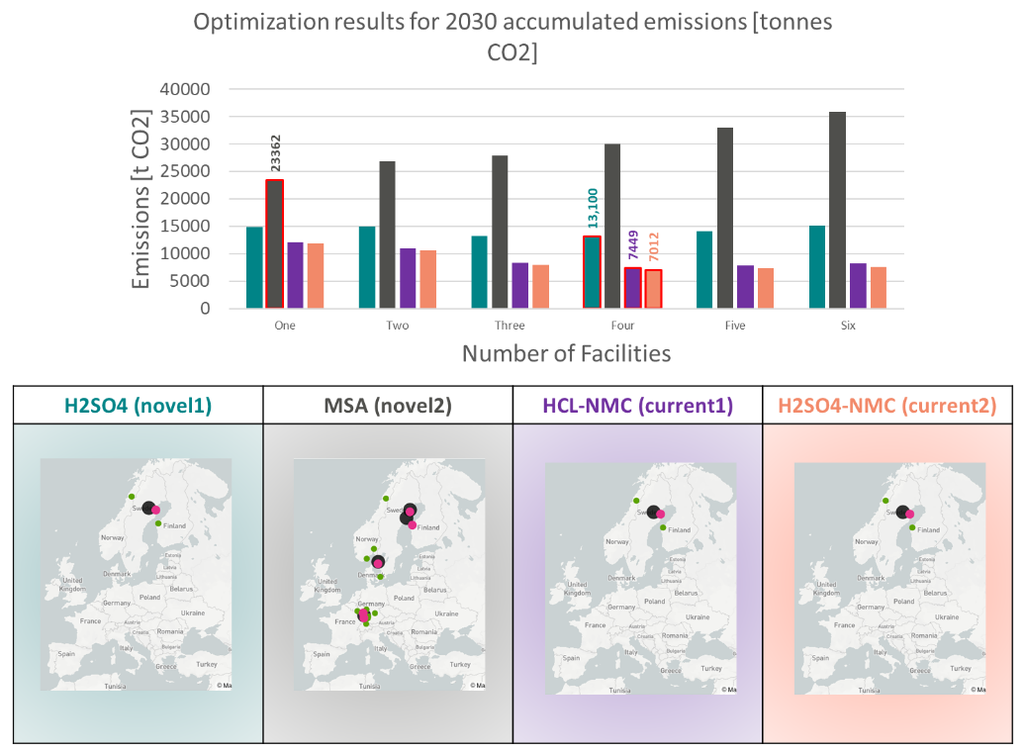

## Personal Projects

*Under construction.*

*A problem well-stated is a problem half-solved.* - Charles F. Kettering

Made with the [Lumo](https://www.productive-r-workflow.com/r/bonus/lumo-quarto-template) theme.